# Time Series Analysis of Electricity Consumption of Turkey

Umut Mete Saka - 2018402228

## Introduction

Electricity is used widely for vast amount of purposes in daily life of households and also businesses in the World. Most production facilities uses electricity, nearly every household has an access to electricity in developing and developed countries. As a developing country, Turkey has met electricity over 100 years ago and it is reported that 100% of Turkish population has an electricity access in 2016[1].

This study aims to understand the behavior of electricity consumption in Turkey in hourly, weekly and monthly time units from 01.01.2016 to 26.04.2020 and make forecasts for the following 24 hours.

The data used in this study is provided from EXIST (Energy Exchange Istanbul) which can be retrieved from [this link.](https://seffaflik.epias.com.tr/transparency/tuketim/gerceklesen-tuketim/gercek-zamanli-tuketim.xhtml)

## First Steps

#### Loading Packages

I used several packages in my study therefore I started with loading them. These packages will be needed to analyze and visualize my data.

```r
library(data.table)
library(zoo)
library(xts)
library(ggplot2)
library(stats)
library(dplyr)
library(forecast)
```

#### Importing data and converting into data.table and changing column names

```r
data_elec <- data.table(read.csv("data_electricity.csv"))
names(data_elec) <- c("Date", "Time" , "Consumption_MWh")
```

Now we can display the structure of the data

```
## Classes 'data.table' and 'data.frame':   37848 obs. of  3 variables:
##  $ Date           : Factor w/ 1577 levels "01.01.2016","01.01.2017",..: 1 1 1 1 1 1 1 1 1 1 ...
##  $ Time           : Factor w/ 24 levels "00:00","01:00",..: 1 2 3 4 5 6 7 8 9 10 ...
##  $ Consumption_MWh: Factor w/ 37427 levels "17.236,67","17.387,69",..: 3888 1985 835 394 296 289 331 266 630 2246 ...
##  - attr(*, ".internal.selfref")=<externalptr>
```

*Table 1 : Structure of the dataset*

#### Manipulating data in order to start our analysis

We need to make some manipulations to make our time series analysis. These are adding month, day, year, weekday and week colunms and converting Consumption data into numeric.

Now our data is ready:

```
## Classes 'data.table' and 'data.frame':   37848 obs. of  8 variables:
##  $ Date           : chr  "01.01.2016" "01.01.2016" "01.01.2016" "01.01.2016" ...
##  $ Time           : Factor w/ 24 levels "00:00","01:00",..: 1 2 3 4 5 6 7 8 9 10 ...
##  $ Consumption_MWh: num  26277 24992 23533 22465 22003 ...
##  $ day            : int  1 1 1 1 1 1 1 1 1 1 ...
##  $ month          : int  1 1 1 1 1 1 1 1 1 1 ...
##  $ year           : int  2016 2016 2016 2016 2016 2016 2016 2016 2016 2016 ...
##  $ Day_of_the_week: chr  "Cuma" "Cuma" "Cuma" "Cuma" ...
##  $ Week           : num  1 1 1 1 1 1 1 1 1 1 ...
##  - attr(*, ".internal.selfref")=<externalptr>
```

*Table 2 : Modified Structure of the dataset*

Consequently we will create 3 new datasets from the hourly data. These will be the daily, weekly and monthly means of consumptions.

```r
data_elec_daily <-  data_elec[,list(daily_total=mean(Consumption_MWh)), by = list(year,month,day)]
data_elec_monthly <- data_elec[,list(monthly_total=mean(Consumption_MWh)), by = list(year,month)]
data_elec_weekly <-  data_elec[,list(weekly_total=mean(Consumption_MWh)), by = list(year,month,Week)]
```

## Analyses

### Task1

#### Creating time series for hourly, daily and weekly and monthly data

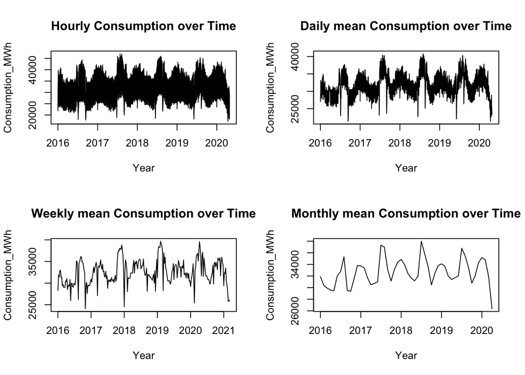

*Figure 1 : Figure of the data in different levels*

It can be seen from these plots that at every unit of time, we observe strong seasonality. To see that dependence to seasonal component, we plot autocorrelation functions.

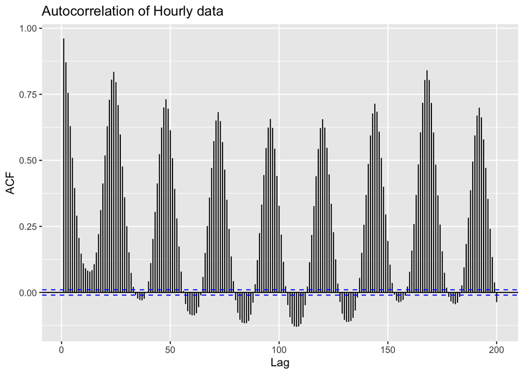

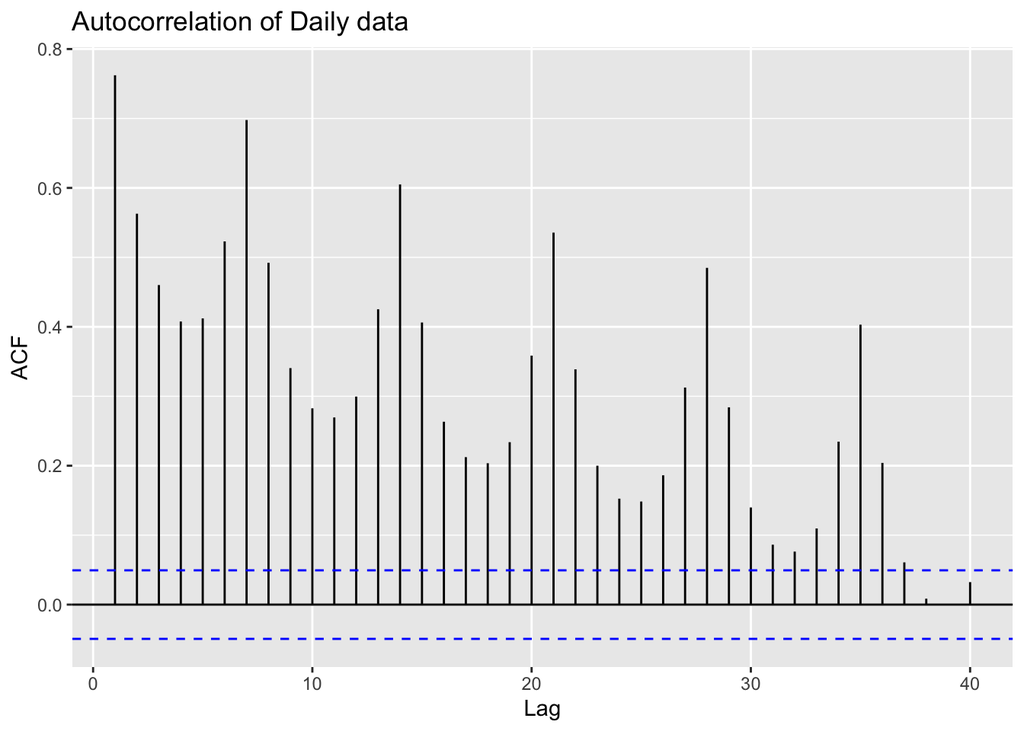

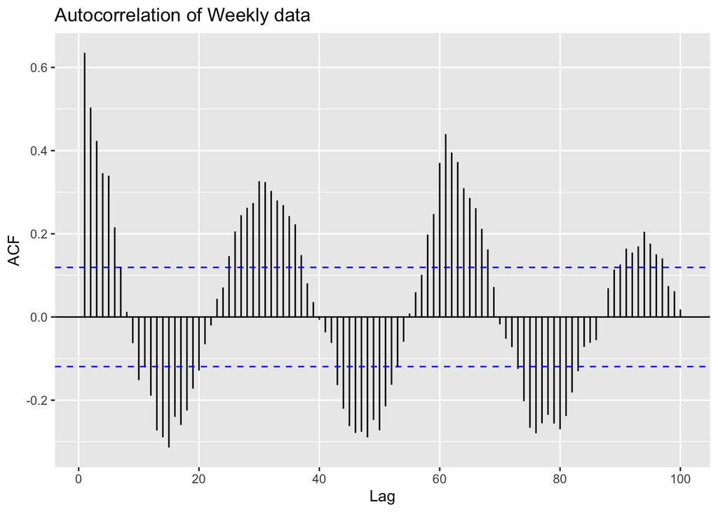

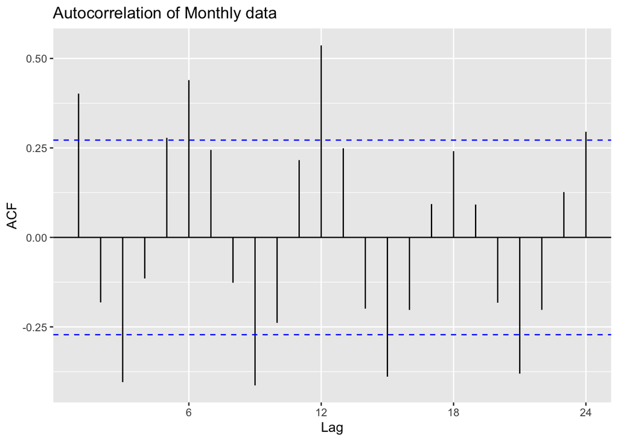

*Figure 2 : Autocorrelation Plots of the data in different levels*

It can be seen that Hourly data has the highest autocorrelation in every 24 hours. This shows a seasonality of a period of 24 hours. Also the hourly data has a strong correlation between the other hours especially the neighboring ones. At lag 168 (7*24) which represents the same hour of the same day of the week, has highest correlation.

The Daily data shows the highest autocorrelation in every 7 days. This shows a seasonality of a period of 7 days. Also the neighboring days indicate correlation within.

Weekly data autocorrelation graph pendulates between - and + like a sinusodial wave. There is a seasonal behaviour but the periods are not exactly equal and it is not as strong as the seasonality in hourly and daily data.

It can be seen that Monthly data has a correlation in every 12 months. In other words there is a correlation between same months of years. This is another seasonality sign but it is not as strong as daily or hourly data.

#### Decomposition of the time series in at different levels

To see seasonality and trend we will decompose and plot our time series.

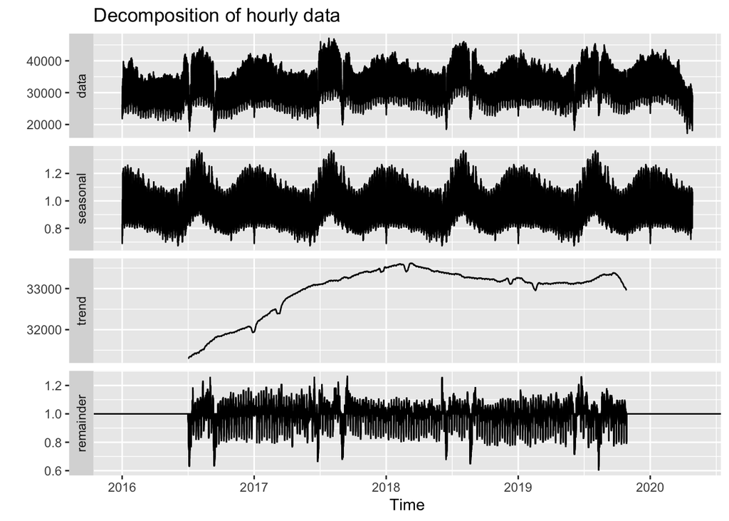

*Figure 3 : Decomposition Plots of the hourly data*

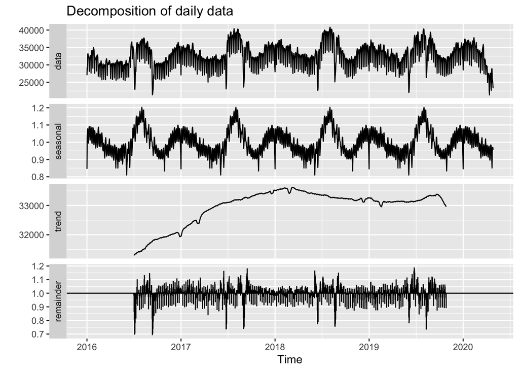

*Figure 4 : Decomposition of the daily series*

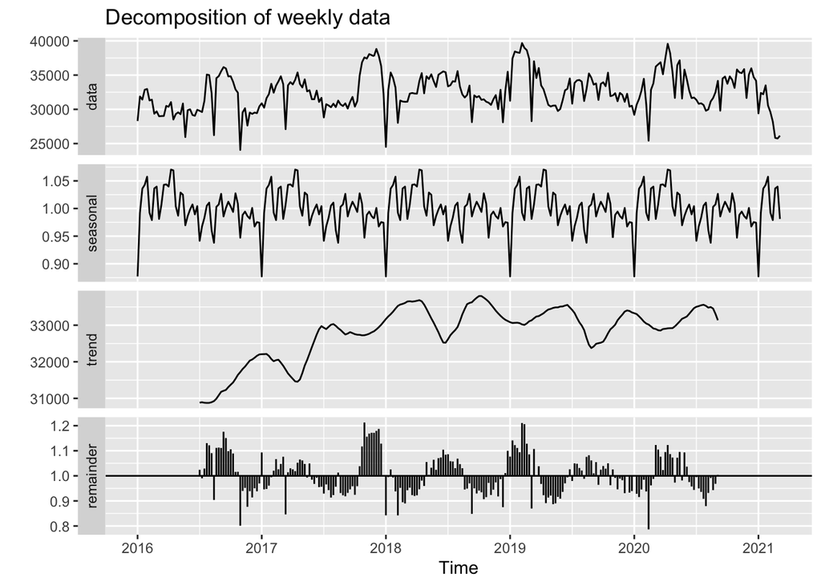

*Figure 5 : Decomposition of the weekly series*

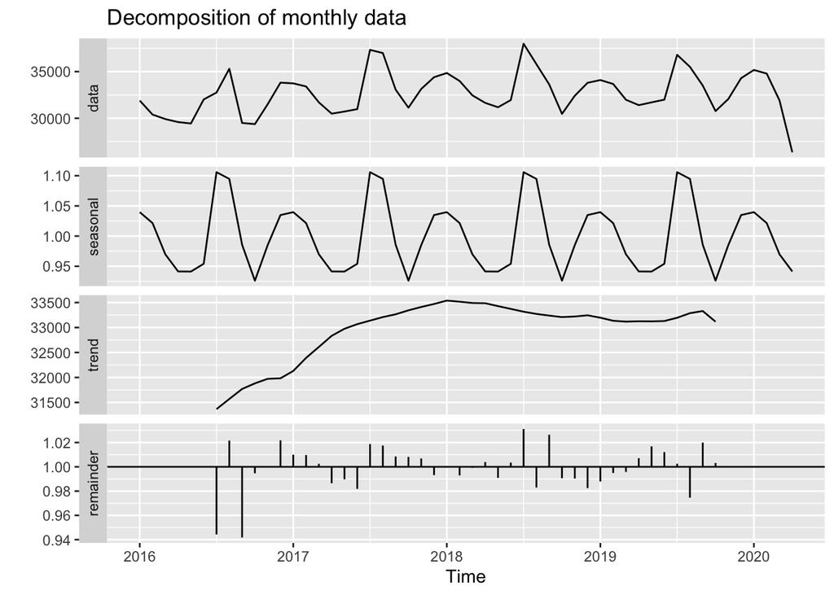

*Figure 6 : Decomposition of the monthly series*

After noticing the most correlation occurs in period of 168 hours, I move on with the hourly time series data. First I will decompose it, detrend it and than deseasonalize it to have the random effect.

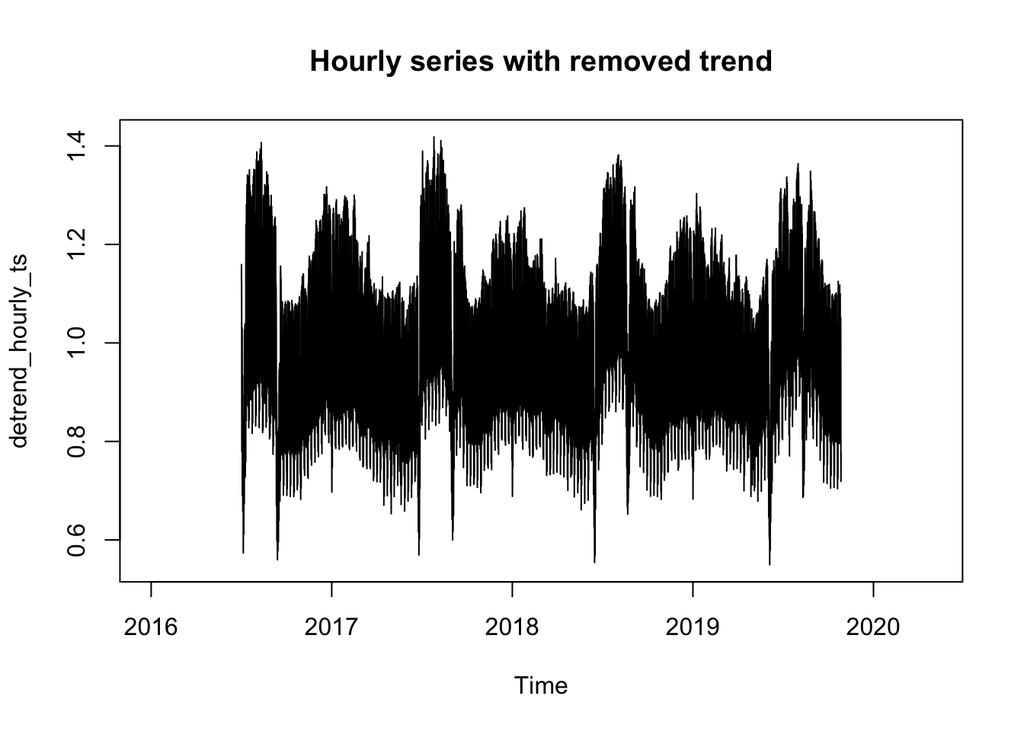

*Plot 7 : Plot of the detrended hourly data*

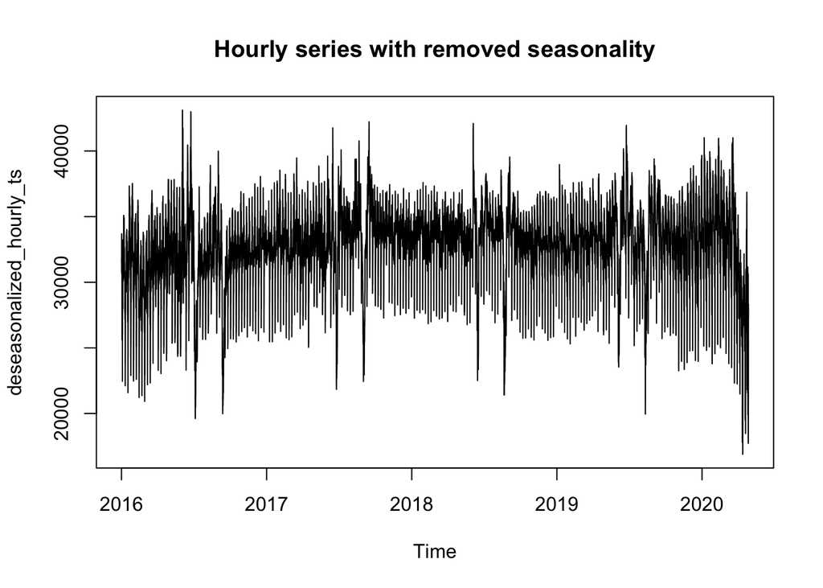

*Plot 8 : Plot of the deseasonalized hourly data*

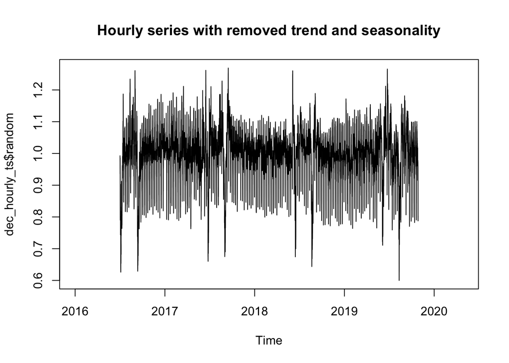

*Plot 9 : Plot of the hourly data with removed trend and seasonality*

#### Autocorrelation of the series with removed trend and seasonality

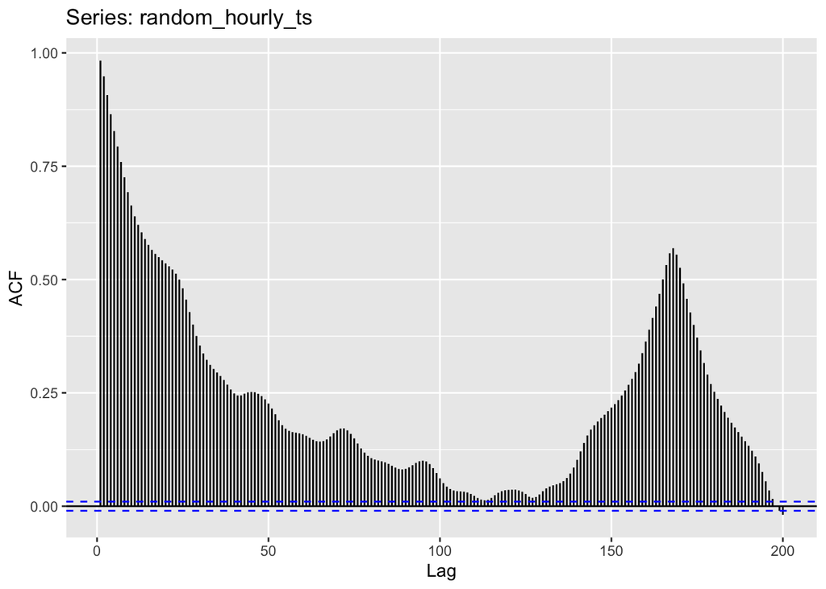

*Plot 10 : Autocorrelation Plot of the hourly data with removed trend and seasonality*

### Task 3

#### Application of Auto Regressive Model

The code runs arima function which evaluates the Auto Regressive Model in different orders (1 to 5).

We will check the Akaike and Bayesian Information criteria

```r
#Akaike Information Criteria
AIC_AR
```

```
## [1] -187536.5 -198541.0 -198658.2 -198744.5 -199299.6
```

```r
#Bayesian Information Criteria
BIC_AR
```

```
## [1] -187511.2 -198507.3 -198616.1 -198694.0 -199240.6
```

The lowest AIC and BIC value seems to be at p = 5

### Task 4

#### Application of Moving Average Model

The code runs arima function which evaluates the Moving Average Model in different orders (1 to 5).

We will check the Akaike and Bayesian Information criteria

```r
#Akaike Information Criteria
AIC_MA
```

```
## [1] -116033.6 -145276.8 -162712.0 -176898.3 -183202.7
```

```r
#Bayesian Information Criteria
BIC_MA
```

```
## [1] -116008.4 -145243.1 -162670.0 -176847.8 -183143.8
```

The lowest AIC and BIC value seems to be at q = 5

The lowest AIC and BIC value of all models happens at AR model with order = 5, therefore we will use that model for our forecast.

### Task 5

#### Making Predictions

We will make 24 hour prediction to the Resudial values of the hourly data, based on our AR model.

Our forecast suggests, for the next 24 hours, the electricity consumption will be like as following:

```
##  [1] 26002.97 24772.40 23905.51 23391.20 23351.25 23469.50 22971.93 23914.54
##  [9] 26628.97 28511.82 29471.42 30062.88 29353.36 29181.91 29681.22 29134.16
## [17] 29488.96 29512.01 29611.60 30986.45 32081.40 31469.56 30725.81 29380.38
```

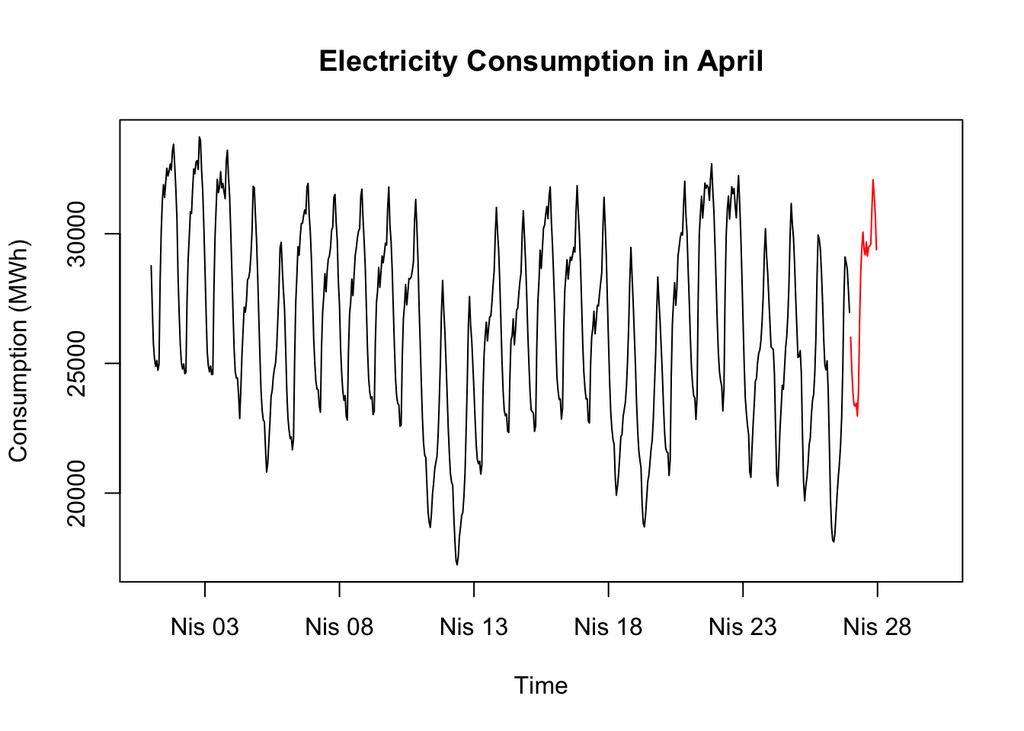

*Figure 11: Electricity consumption in April (Forecast is shown with red line*

### Bonus: Checking model success

In this part we will test our forecast with the real values of the consumption in 27 April 2020.

```r
test_data <- fread("test_data.csv")
names(test_data) <- c("Date", "Time" , "Consumption_MWh")


test_data$Consumption_MWh <- as.character(test_data$Consumption_MWh)
temp7 <- c()
for(i in 1:length(test_data$Consumption_MWh)){
  temp8 <- 1000*as.numeric(paste(unlist(strsplit(test_data$Consumption_MWh[i],",")),collapse = ""))
  temp7 <- c(temp7,temp8)
}
test_data$Consumption_MWh <- temp7

Real_life_consumption <- test_data$Consumption_MWh
```

Mean Absolute Percentage Error:

```r
mean(abs(Forecasted_values-Real_life_consumption)/Real_life_consumption)
```

```
## [1] 0.04793721
```

Root Mean Square Error:

```r
mean((Forecasted_values-Real_life_consumption)^2)^0.5
```

```
## [1] 1516.055
```

When we consider MAPE and RMSE values, MAPE gives a better insight on the fit of the model. A MAPE value of 4.8% gives a good understanding of the fit compared to an rmse value of 1516.

## References

[R documentation](https://www.rdocumentation.org/)

[EXIST - Transparency Platform](https://seffaflik.epias.com.tr/transparency/tuketim/gerceklesen-tuketim/gercek-zamanli-tuketim.xhtml)

1.[Trading Eceonomics (About Turkish electricity access)](https://tradingeconomics.com/turkey/access-to-electricity-percent-of-total-population-wb-data.html)